# Project1 Part1 Applied Statistics

Abhina Premachandran

2023-10-08

## Monte Carlo Simulations of DIS and HPQ stocks

This project uses Monte Carlo Simulations to simulate daily returns of an investment portfolio. The simulated return mean is compared with actual return mean. The chosen stocks for this project are ‘DIS’ and ‘HPQ’ stocks. Further an optimal portfolio is suggested based on three scenarios on investing the amount on DIS and HPQ stocks.

Getting the stock data using `getSymbols`.

```r
getSymbols(c('DIS','HPQ'), from = Sys.Date() - 150, to = Sys.Date())
```

```
## [1] "DIS" "HPQ"
```

plotting to see the timeseries of DIS and HPQ stocks for the past 150 days

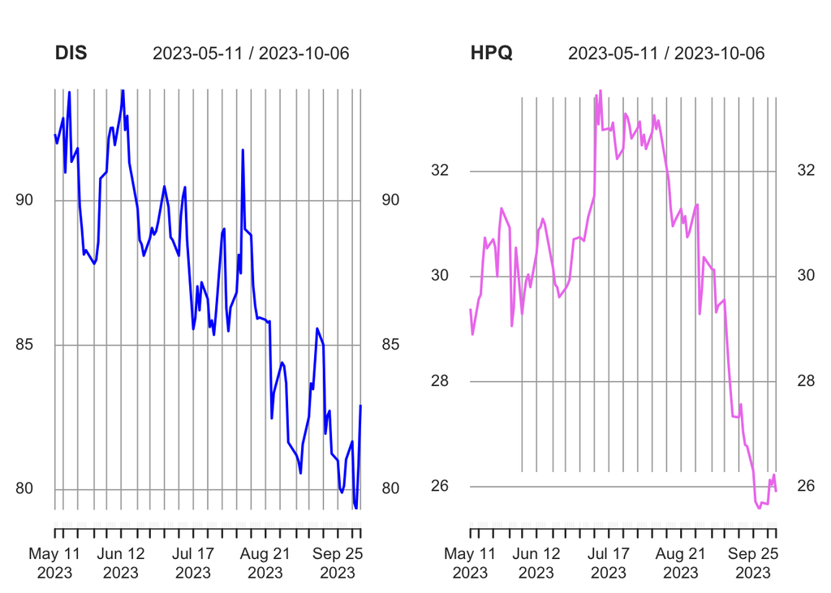

```r
par(mfrow = c(1,2))
plot(DIS$DIS.Close, main = 'DIS',type = 'l',col = 'blue', lwd = 2)
plot(HPQ$HPQ.Close, main = 'HPQ',type = 'l',col = 'violet', lwd = 2)
```

Defining the stock price matrix for each stocks

```r
DIS_Price <- as.matrix(as.numeric(DIS$DIS.Close))
HPQ_Price <- as.matrix(as.numeric(HPQ$HPQ.Close))
```

## computing the daily returns using diff()/lag() of Closing prices

```r
DIS$DIS.Returns <- diff(DIS$DIS.Close)/lag(DIS$DIS.Close)
Returns_DIS <- DIS$DIS.Returns
```

```r
HPQ$HPQ.Returns <- diff(HPQ$HPQ.Close)/lag(HPQ$HPQ.Close)
Returns_HPQ <- HPQ$HPQ.Returns
#Defining N_days as the length of the time series
N_days <- length(Returns_HPQ)
```

## Plotting the daily returns

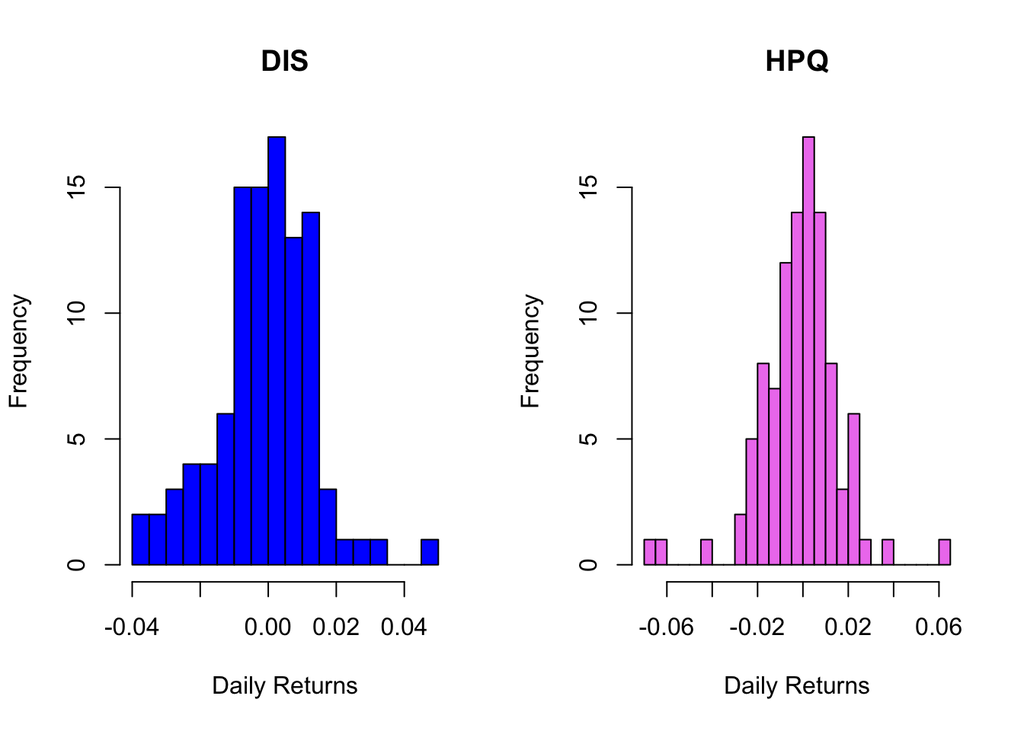

```r
par(mfrow = c(1, 2))
hist(Returns_DIS,main = 'DIS', xlab = 'Daily Returns', col='blue',breaks = 20, freq=TRUE)
hist(Returns_HPQ,main = 'HPQ', xlab = 'Daily Returns', col='violet',breaks = 20, freq=TRUE)
```

From the histogram of each stock, it is clear that the daily returns of the stocks approximately follows a normal distribution. Therefore rnorm() can be used to simulate future returns. ## Computing the mean and standard deviation from the past stock returns inorder to simulate future returns I am choosing the returns upto 30 days before as the past data to simulate the rest of the 30 days(future stock) until today

```r
#To simulate for 30 days until today

DIS_daily_mean <- mean(Returns_DIS[(N_days-31):N_days])
DIS_daily_std <- sd(Returns_DIS[(N_days-31):N_days])

HPQ_daily_mean <- mean(Returns_HPQ[(N_days-31):N_days])
HPQ_daily_std <- sd(Returns_HPQ[(N_days-31):N_days])
```

## Monte Carlo Simulation for DIS

rnorm() is used to simulate returns and price for 30 days until today for DIS stock.

```r
set.seed(101)
DIS_starting_price <- DIS$DIS.Close[[(N_days-30)]]
returns <- 1+rnorm(30,mean=DIS_daily_mean,sd=DIS_daily_std)
no_sims <- 1001
return_list <- matrix(0, nrow=no_sims,ncol=30)
price_list <- matrix(0,nrow=no_sims,ncol=31)
for(i in 1:no_sims){
  return_list[i,]<-rnorm(30,mean=DIS_daily_mean,sd=DIS_daily_std)
  price_list[i,]<-cumprod(c(DIS_starting_price,1+return_list[i,]))
}
total_returns1 <- array(NA,dim=no_sims,dimnames=NULL)
for(i in 1:no_sims){
  total_returns1[i]<-(price_list[i,31]-price_list[i,1])/price_list[i,1]
}
```

## Analysing and visualizing the simulations for DIS

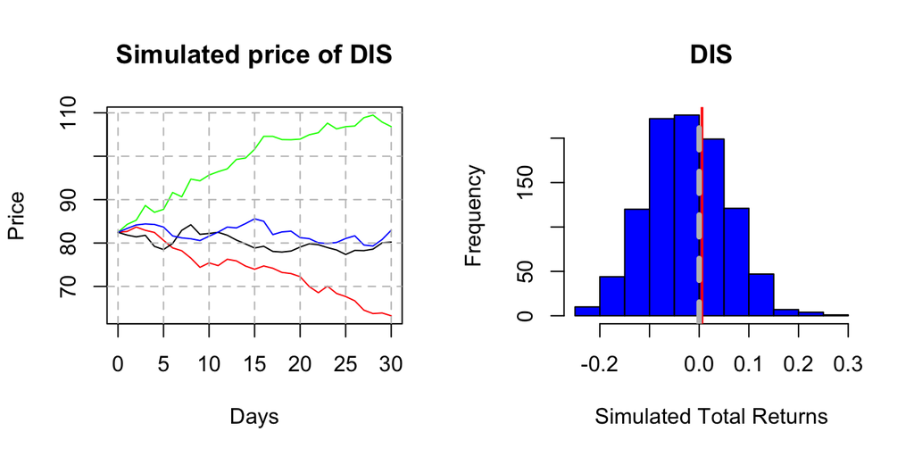

```r
max1<-which.max(total_returns1)
min1<-which.min(total_returns1)
actual_prices_DIS <- as.matrix(as.numeric(DIS$DIS.Close[(N_days-30):N_days]))
med1<-match(median(total_returns1),total_returns1)

par(mfrow = c(1,2))
lb <- min(price_list[min1,])
ub <- max(price_list[max1,])

#Plotting the min, max, median of the simulated return along with the actual return
plot(0:30, price_list[min1,], type='l', main = 'Simulated price of DIS',ylab='Price',xlab='Days',ylim=c(lb,ub),col="red")
lines(0:30, price_list[med1,],type='l',col='black')
lines(0:30, price_list[max1,],type='l',col='green')
lines(0:30, actual_prices_DIS,type='l',col='blue')
grid(lty = 2, col = 'gray', lwd = 1)

hist(total_returns1, main = 'DIS', xlab = 'Simulated Total Returns', col='blue', freq=TRUE)
actual_return1=(DIS$DIS.Close[[N_days]]-DIS$DIS.Close[[(N_days-30)]])/DIS$DIS.Close[[(N_days-30)]]
abline(v=actual_return1, col = 'red', lwd=2)
abline(v=0, col = 'gray', lty=2, lwd=4)
```

```r
DIS_expected_return <- mean(total_returns1)
DIS_return_std <- sd(total_returns1)

summary(total_returns1)
```

```
##     Min.  1st Qu.   Median     Mean  3rd Qu.     Max.
## -0.23319 -0.07897 -0.02723 -0.02549  0.02833  0.29524
```

```r
actual_return1
```

```
## [1] 0.005699057
```

The summary statistics from all Monte Carlo trials had an average of -0.0254947. The actual return is 0.0056991. The actual and simulated returns for DIS stocks are not close.

## Estimating the probability of gaining or losing more than 10% return during the selected time period for DIS

```r
DIS_prob_G<-sum(total_returns1 > 0.1)/no_sims
DIS_prob_L<-sum(total_returns1 < (-0.1))/no_sims
```

## Monte Carlo Simulation for HPQ

```r
set.seed(101)
HPQ_starting_price <- HPQ$HPQ.Close[[(N_days-30)]]
returns <- 1+rnorm(30,mean=HPQ_daily_mean,sd=HPQ_daily_std)
no_sims <- 1001
return_list <- matrix(0, nrow=no_sims,ncol=30)
price_list <- matrix(0,nrow=no_sims,ncol=31)
for(i in 1:no_sims){
  return_list[i,]<-rnorm(30,mean=HPQ_daily_mean,sd=HPQ_daily_std)
  price_list[i,]<-cumprod(c(HPQ_starting_price,1+return_list[i,]))
}
total_returns2 <- array(NA,dim=no_sims,dimnames=NULL)
for(i in 1:no_sims){
  total_returns2[i]<-(price_list[i,31]-price_list[i,1])/price_list[i,1]
}
```

## Analysing and visualizing the simulations for HPQ

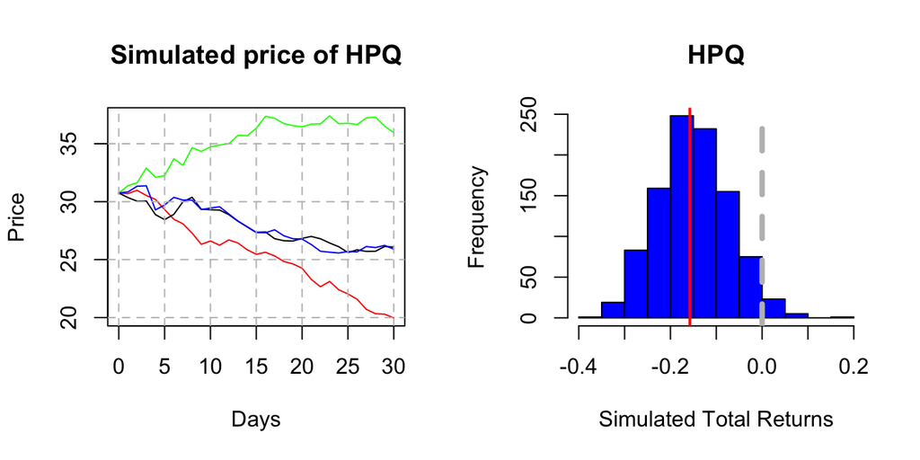

```r
max2<-which.max(total_returns2)
min2<-which.min(total_returns2)
actual_prices_HPQ <- as.matrix(as.numeric(HPQ$HPQ.Close[(N_days-30):N_days]))
med2<-match(median(total_returns2),total_returns2)

par(mfrow = c(1,2))
lb <- min(price_list[min2,])
ub <- max(price_list[max2,])

#Plotting the min, max, median of the simulated return along with the actual return
plot(0:30, price_list[min2,], type='l', main = 'Simulated price of HPQ',ylab='Price',xlab='Days',ylim=c(lb,ub),col="red")
lines(0:30, price_list[med2,],type='l',col='black')
lines(0:30, price_list[max2,],type='l',col='green')
lines(0:30, actual_prices_HPQ,type='l',col='blue')
grid(lty = 2, col = 'gray', lwd = 1)

hist(total_returns2, main = 'HPQ', xlab = 'Simulated Total Returns', col='blue', freq=TRUE)
actual_return2=(HPQ$HPQ.Close[[N_days]]-HPQ$HPQ.Close[[(N_days-30)]])/HPQ$HPQ.Close[[(N_days-30)]]
abline(v=actual_return2, col = 'red', lwd=2)
abline(v=0, col = 'gray', lty=2, lwd=4)
```

```r
HPQ_expected_return <- mean(total_returns2)
HPQ_return_std <- sd(total_returns2)

summary(total_returns2)
```

```
##     Min.  1st Qu.   Median     Mean  3rd Qu.     Max.
## -0.35044 -0.20210 -0.15164 -0.14963 -0.09734  0.16925
```

```r
mean(actual_return2)
```

```
## [1] -0.1577236
```

The summary statistics from all Monte Carlo trials had an average of -0.1496264. The actual return is -0.1577236. The actual and simulated returns are almost similar for HPQ, thereby the model is accurate for predictions.

## Estimating the probability of gaining or losing more than 10% return during the selected time period for HPQ

```r
HPQ_prob_G<-sum(total_returns2 > 0.1)/no_sims
HPQ_prob_L<-sum(total_returns2 < (-0.1))/no_sims
```

## Building a portfolio

We will assume an Initial Investment of $10,000 and allocate our funds between these two stocks based on 3 strategies:

- The entire investment to DIS
- The entire investment to HPQ
- Split the investment evenly between DIS and HPQ

From the previous computations, the cost of DIS is $82.47. Our analysis has shown that their expected return is $-0.0255 per share with a standard deviation of $0.0794. Shares of HPQ cost $30.75 per share, with an expected return of $-0.1496 and a standard deviation of $0.0777. We will assume that the returns from the two companies are independent.

```r
Initial_Investment <- 10000

X <- round(DIS_expected_return, digits=4)
st_X <- round(DIS_return_std, digits=4)
num_X <- Initial_Investment/round(DIS_starting_price,2)

Y <- round(HPQ_expected_return, digits=4)
st_Y <- round(HPQ_return_std, digits=4)
num_Y <- Initial_Investment/round(HPQ_starting_price,2)

E_X <- num_X*X
Var_X <- (st_X*num_X)^2

E_Y <- num_Y*Y
Var_Y <- (st_Y*num_Y)^2

E_C <- (num_X/2)*X + (num_Y/2)*Y
Var_C <- (st_X*num_X/2)^2 + (st_Y*num_Y/2)^2
```